# Random Forest - Regression

## Plus: An Additional Analysis of Various Regression Methods!

## The Data

We just got hired by a tunnel boring company which uses X-rays in an attempt to know rock density, ideally this will allow them to switch out boring heads on their equipment before having to mine through the rock!

[figure not shown]

```python
import numpy as np
import pandas as pd
import matplotlib.pyplot as plt
import seaborn as sns
```

```python
df = pd.read_csv("../DATA/rock_density_xray.csv")
```

```python
df.head()
```

|  | Rebound Signal Strength nHz | Rock Density kg/m3 |
| --- | --- | --- |
| 0 | 72.945124 | 2.456548 |
| 1 | 14.229877 | 2.601719 |
| 2 | 36.597334 | 1.967004 |
| 3 | 9.578899 | 2.300439 |
| 4 | 21.765897 | 2.452374 |

```python
df.columns=['Signal',"Density"]
```

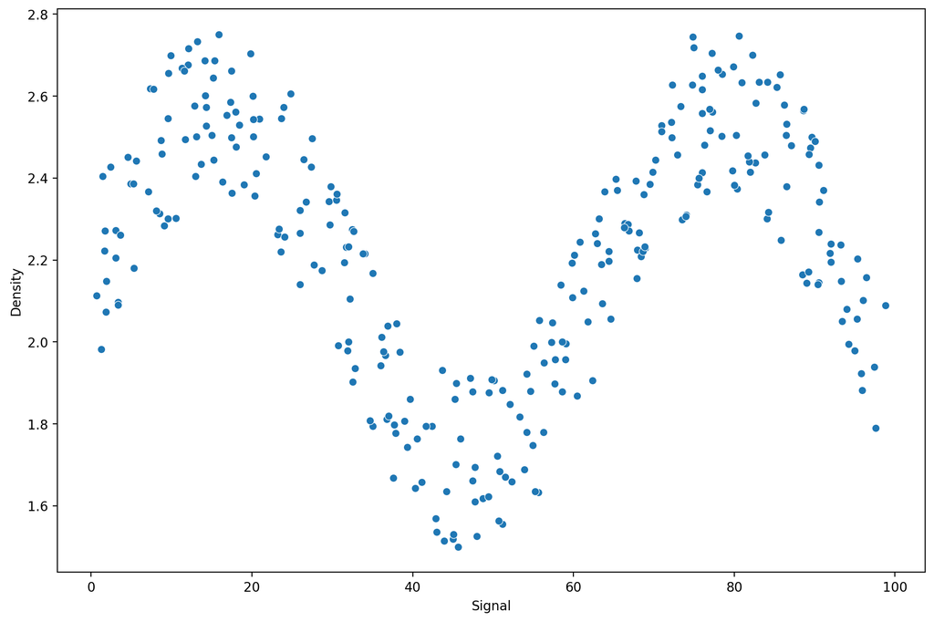

```python
plt.figure(figsize=(12,8),dpi=200)
sns.scatterplot(x='Signal',y='Density',data=df)
```

## Splitting the Data

Let's split the data in order to be able to have a Test set for performance metric evaluation.

```python
X = df['Signal'].values.reshape(-1,1)
y = df['Density']
```

```python
from sklearn.model_selection import train_test_split
```

```python
X_train, X_test, y_train, y_test = train_test_split(X, y, test_size=0.1, random_state=101)
```

# Linear Regression

```python
from sklearn.linear_model import LinearRegression
```

```python
lr_model = LinearRegression()
```

```python
lr_model.fit(X_train,y_train)
```

```
LinearRegression()
```

```python
lr_preds = lr_model.predict(X_test)
```

```python
from sklearn.metrics import mean_squared_error
```

```python
np.sqrt(mean_squared_error(y_test,lr_preds))
```

```
0.2570051996584629
```

What does the fit look like?

```python
signal_range = np.arange(0,100)
```

```python
lr_output = lr_model.predict(signal_range.reshape(-1,1))
```

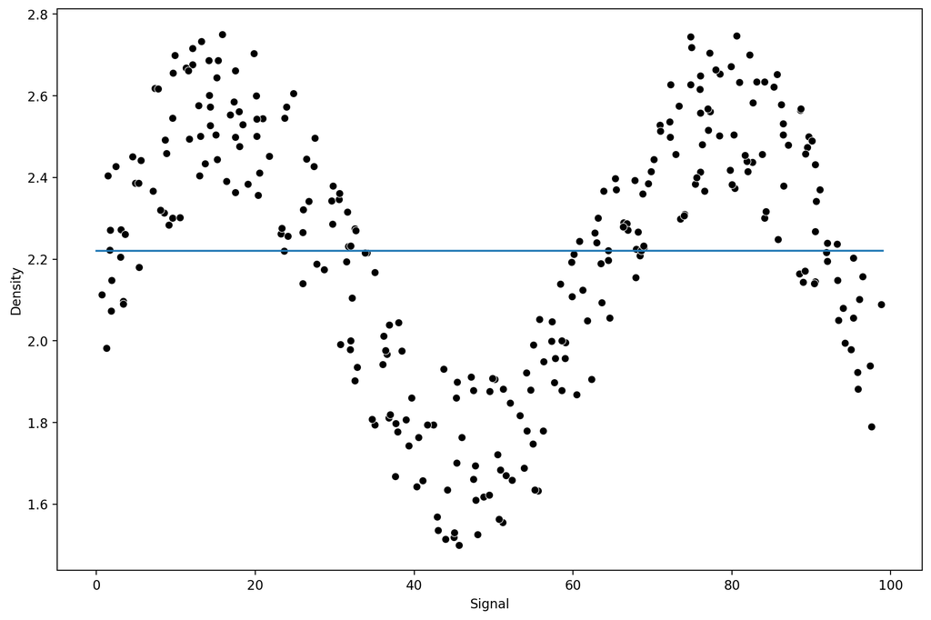

```python
plt.figure(figsize=(12,8),dpi=200)
sns.scatterplot(x='Signal',y='Density',data=df,color='black')
plt.plot(signal_range,lr_output)
```

# Polynomial Regression

## Attempting with a Polynomial Regression Model

Let's explore why our standard regression approach of a polynomial could be difficult to fit here, keep in mind, we're in a fortunate situation where we can easily visualize results of y vs x.

## Function to Help Run Models

```python
from sklearn.linear_model import LinearRegression
model = LinearRegression()
```

```python
def run_model(model,X_train,y_train,X_test,y_test):

    # Fit Model
    model.fit(X_train,y_train)

    # Get Metrics

    preds = model.predict(X_test)

    rmse = np.sqrt(mean_squared_error(y_test,preds))
    print(f'RMSE : {rmse}')

    # Plot results
    signal_range = np.arange(0,100)
    output = model.predict(signal_range.reshape(-1,1))


    plt.figure(figsize=(12,6),dpi=150)
    sns.scatterplot(x='Signal',y='Density',data=df,color='black')
    plt.plot(signal_range,output)
```

```
RMSE : 0.2570051996584629
```

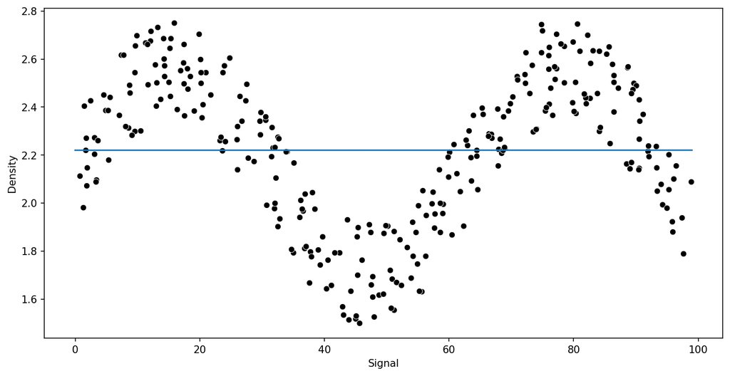

```python
run_model(model,X_train,y_train,X_test,y_test)
```

## Pipeline for Poly Orders

```python
from sklearn.pipeline import make_pipeline
```

```python
from sklearn.preprocessing import PolynomialFeatures
```

```python
pipe = make_pipeline(PolynomialFeatures(2),LinearRegression())
```

```
RMSE : 0.2817309563725596
```

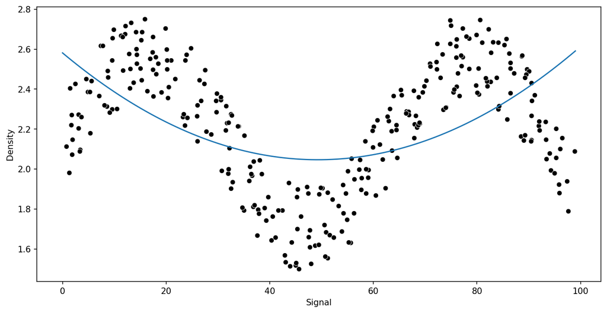

```python
run_model(pipe,X_train,y_train,X_test,y_test)
```

## Comparing Various Polynomial Orders

```
RMSE : 0.1417947898442399
```

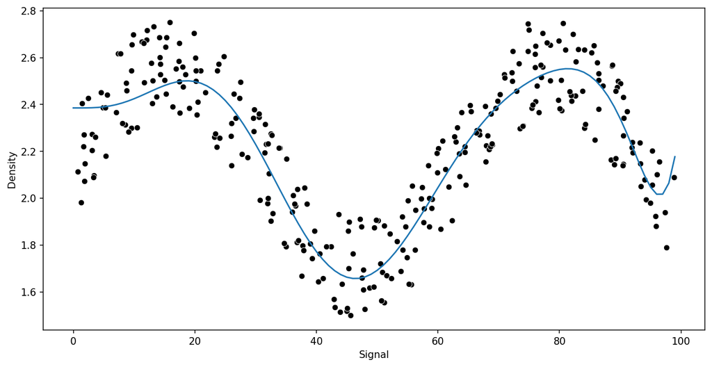

```python
pipe = make_pipeline(PolynomialFeatures(10),LinearRegression())
run_model(pipe,X_train,y_train,X_test,y_test)
```

## KNN Regression

```python
from sklearn.neighbors import KNeighborsRegressor
```

```
RMSE : 0.15234870286353372
RMSE : 0.13730685016923655
RMSE : 0.13277855732740926
```

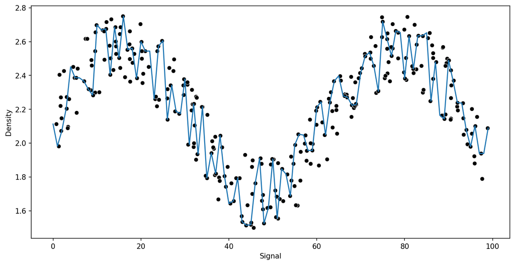

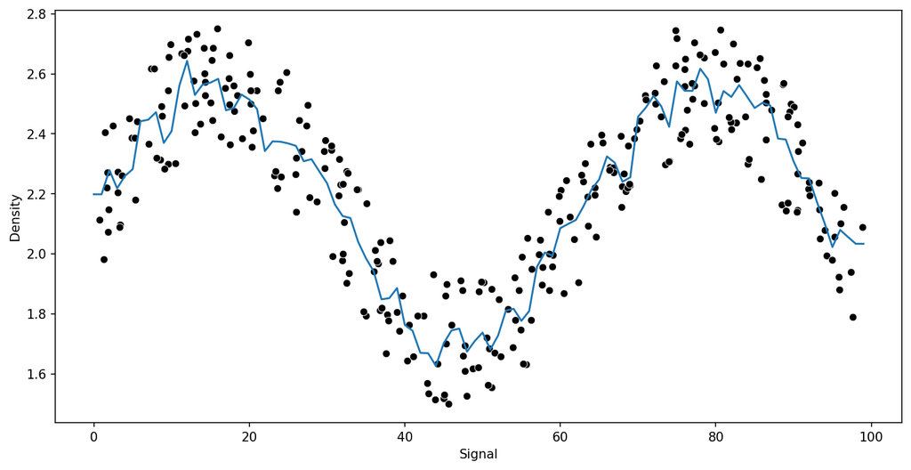

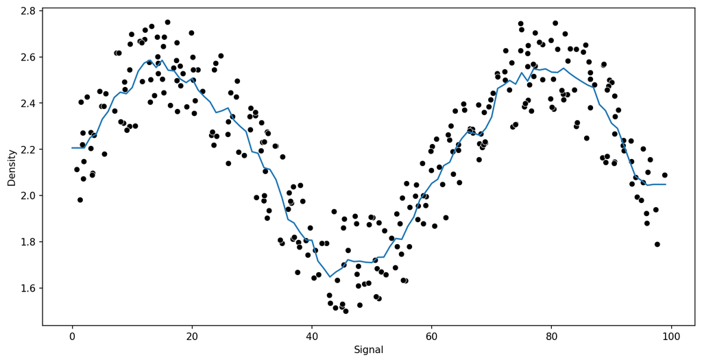

```python
preds = {}
k_values = [1,5,10]
for n in k_values:


    model = KNeighborsRegressor(n_neighbors=n)
    run_model(model,X_train,y_train,X_test,y_test)
```

## Decision Tree Regression

```python
from sklearn.tree import DecisionTreeRegressor
```

```
RMSE : 0.15234870286353372
```

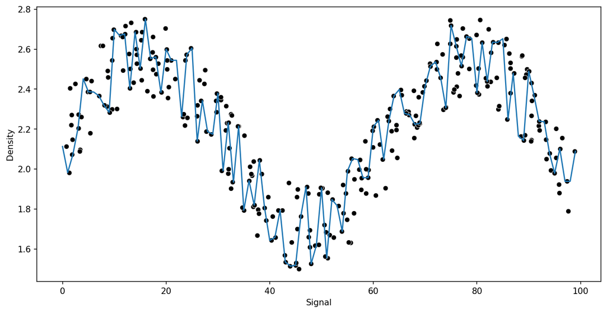

```python
model = DecisionTreeRegressor()

run_model(model,X_train,y_train,X_test,y_test)
```

```python
model.get_n_leaves()
```

```
270
```

## Support Vector Regression

```python
from sklearn.svm import SVR
```

```python
from sklearn.model_selection import GridSearchCV
```

```python
param_grid = {'C':[0.01,0.1,1,5,10,100,1000],'gamma':['auto','scale']}
svr = SVR()
```

```python
grid = GridSearchCV(svr,param_grid)
```

```
RMSE : 0.12634668775105407
```

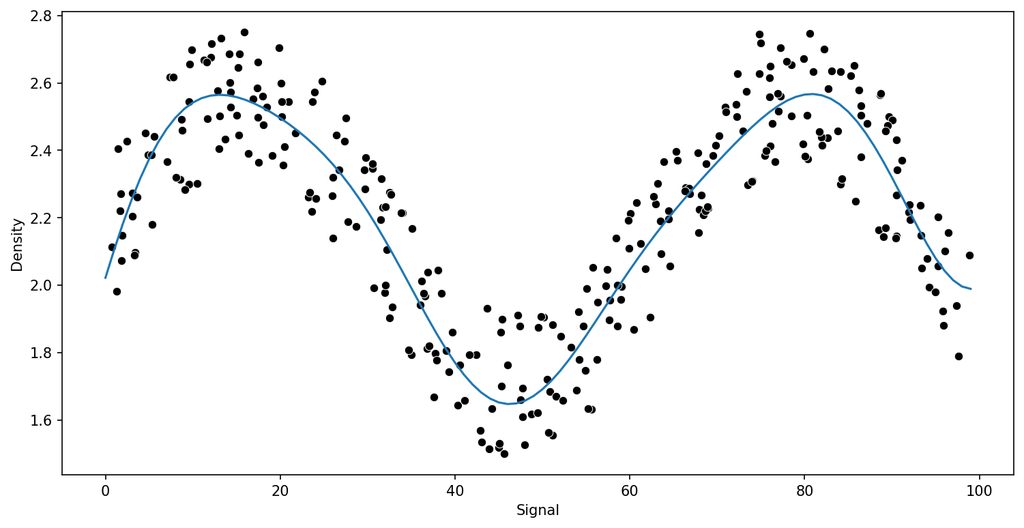

```python
run_model(grid,X_train,y_train,X_test,y_test)
```

```python
grid.best_estimator_
```

```
SVR(C=1000)
```

## Random Forest Regression

```python
from sklearn.ensemble import RandomForestRegressor
```

```python
# help(RandomForestRegressor)
```

```
RMSE : 0.1417613358931285
RMSE : 0.133281449397454
RMSE : 0.13699094997283662
```

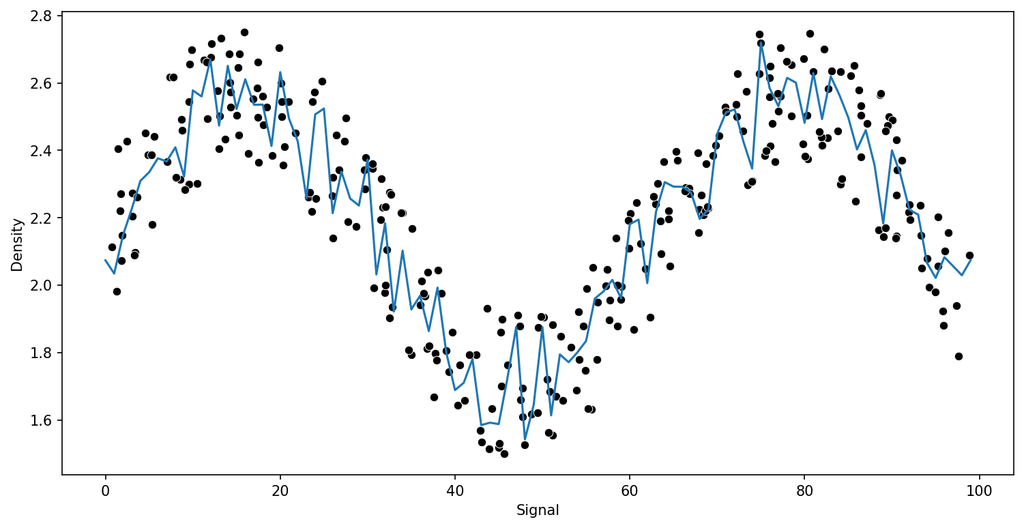

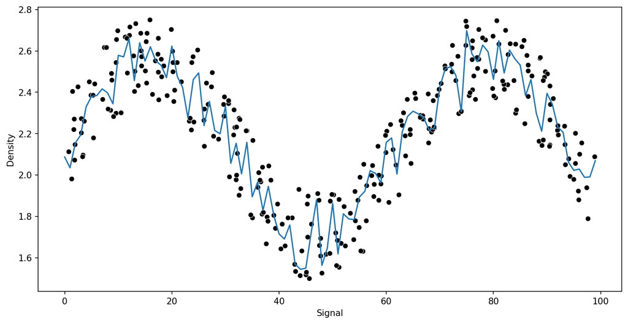

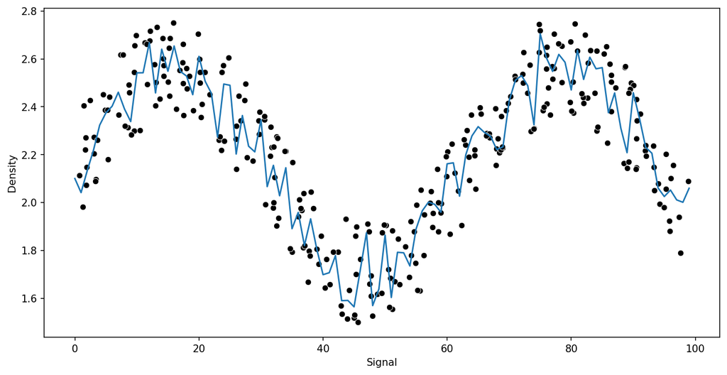

```python
trees = [10,50,100]
for n in trees:

    model = RandomForestRegressor(n_estimators=n)

    run_model(model,X_train,y_train,X_test,y_test)
```

## Gradient Boosting

We will cover this in more detail in next section.

```python
from sklearn.ensemble import GradientBoostingRegressor
```

```python
# help(GradientBoostingRegressor)
```

```
RMSE : 0.13294148649584667
```

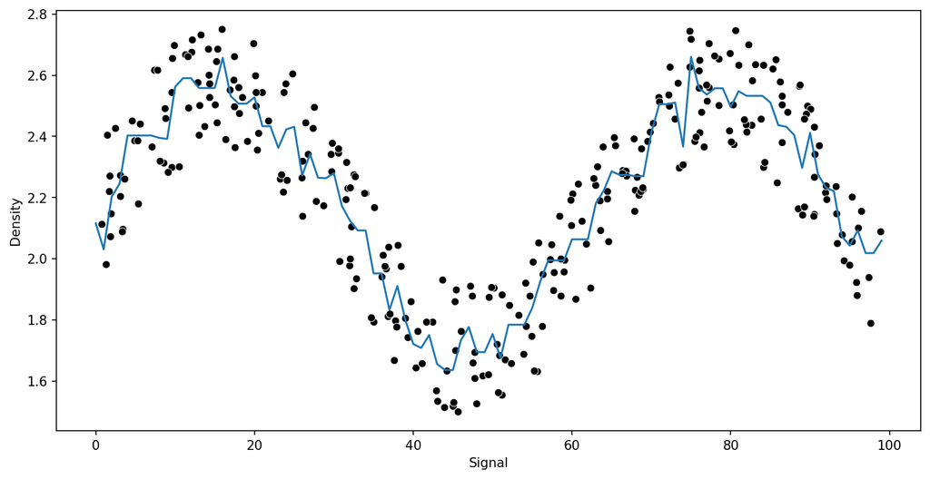

```python
model = GradientBoostingRegressor()

run_model(model,X_train,y_train,X_test,y_test)
```

```python
from sklearn.ensemble import AdaBoostRegressor
```

```
RMSE : 0.13294148649584667
```

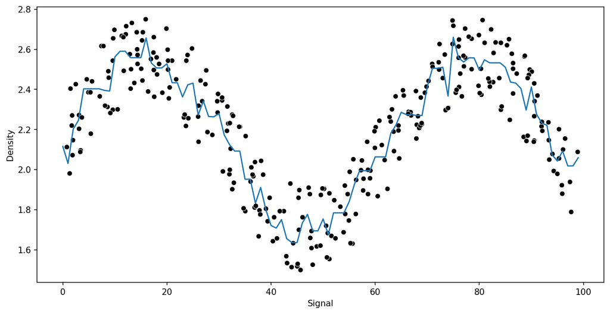

```python
model = GradientBoostingRegressor()

run_model(model,X_train,y_train,X_test,y_test)
```